# OHIBC: Fishing licenses prep

## 3.5 Reference point as % FN in rgn?

One possible reference point is that the % of licenses apportioned to FN should be proportional to the % of population in region that is First Nations.

- Use census data from 2011 or 2016, mapped using the inland regions (full watersheds).
- Use population of First Nations communities vs total population.
- It may be desirable to set a lower limit to ensure some minimal representation of First Nations in a region’s fishing population.

```r
ohibc_rgn <- read_sf(dsn = dir_spatial,
                     layer = 'ohibc_rgns_unclipped')

csd_clean <- function(csd_sf, year) {
  csd_sf2 <- csd_sf %>%
    clean_df_names() %>%
    select(csduid, csdname, csdtype, geometry) %>%
    st_transform(st_crs(ohibc_rgn))

  csd_sf2$a_tot <- st_area(csd_sf)

  csd_sf_bc <- csd_sf2 %>%
    st_buffer(dist = 0) %>%
    st_intersection(ohibc_rgn)

  csd_sf_bc$a_ohibc <- st_area(csd_sf_bc)

  csd_bc_df <- csd_sf_bc %>%
    as.data.frame() %>%
    clean_df_names()  %>%
    mutate(prop_area = as.numeric(a_ohibc / a_tot),
           area_total_km2 = as.numeric(a_tot / 1e6),
           area_ohibc_km2 = as.numeric(a_ohibc / 1e6),
           year = year) %>%
    select(csduid, csdname, csdtype, rgn_id,
           area_total_km2, area_ohibc_km2, prop_area, year)

  return(csd_bc_df)
}

if(!file.exists(file.path(dir_goal, 'int/ao_licenses_csd_2016.csv'))) {

  csd_2016 <- read_sf(dsn = file.path(dir_anx, '_raw_data/bcstats/csd2016carto'),
                      layer = 'lcsd000b16a_e') %>%
    csd_clean(2016)

  write_csv(csd_2016, file.path(dir_goal, 'int/ao_licenses_csd_2016.csv'))

}
```

```r
pop_2016 <- read_csv(file.path(dir_anx, '_raw_data/bcstats',
                               '2016 Census - CSD_control_79d4a796-2ccd-4732-a01c-1a8fd26d254a_1.csv')) %>%
  clean_df_names() %>%
  select(sgc, name, type,
         pop = `2016_population`,
         prev_pop = `2011_population_2`)

write_csv(pop_2016, file.path(dir_goal, 'int/ao_licenses_pop_2016.csv'))
```

```r
pop_df <- read_csv(file.path(dir_goal, 'int/ao_licenses_pop_2016.csv'))

csd_df <- read_csv(file.path(dir_goal, 'int/ao_licenses_csd_2016.csv'))

pop_csd <- pop_df %>%
  left_join(csd_df, by = c('sgc' = 'csduid')) %>%
  filter(!is.na(rgn_id)) %>%
  select(-type, -name, -prev_pop) %>%
  group_by(rgn_id, csdtype) %>%
  summarize(pop = sum(pop * prop_area, na.rm = TRUE))

write_csv(pop_csd, file.path(dir_goal, 'int/ao_licenses_pop_csd_2016.csv'))
```

### 3.5.1 Determine population of First Nations communities within OHIBC

Develop a dataframe of municipalities by OHIBC region (inland, based on MaPP inland regions and watershed boundaries). Census subdivisions will be allocated to OHIBC regions according to area-weighting.

First Nations communities can be identified from the census data using the “type” codes:

| CSD type | Description |
| --- | --- |
| CY | City |
| DM | District Municipality |
| T | Town |
| VL | Village |
| IM | Island Municipality |
| IRI ✓ | Indian Reserve |
| RDA | Regional District Electoral Area |
| IGD ✓ | Indian Governmental District |
| S-E ✓ | Indian Settlement |
| NL ✓ | Nisga’a Land |
| NVL ✓ | Nisga’a Village |

Note, this does not catch First Nations members who are living separately from these communities, and counts all members of the communities as First Nations members.

```r
pop_csd <- read_csv(file.path(dir_goal, 'int/ao_licenses_pop_csd_2016.csv'))

fn_types <- c('IRI', 'IGD', 'S-E', 'NL', 'NVL') %>%
  paste(collapse = '|')

pop_fn_rgn <- pop_csd %>%
  group_by(rgn_id) %>%
  mutate(fn_pop = str_detect(csdtype, fn_types)) %>%
  summarize(fn_pop = sum(pop * fn_pop),
            tot_pop = sum(pop),
            pct_fn_pop = round(fn_pop / tot_pop, 5))


knitr::kable(pop_fn_rgn, caption = 'First Nations communities as percent of total pop')
```

First Nations communities as percent of total pop

| rgn_id | fn_pop | tot_pop | pct_fn_pop |
| --- | --- | --- | --- |
| 1 | 3178.346 | 4.415680e+04 | 0.07198 |
| 2 | 1435.355 | 4.328024e+03 | 0.33164 |
| 3 | 2259.224 | 3.625213e+03 | 0.62320 |
| 4 | 2336.893 | 3.324516e+04 | 0.07029 |
| 5 | 4937.957 | 3.328312e+05 | 0.01484 |
| 6 | 28014.948 | 3.253829e+06 | 0.00861 |
| 8 | 0.000 | 1.009863e+00 | 0.00000 |

```r
write_csv(pop_fn_rgn, file.path(dir_goal, 'output/ao_licenses_fn_pop.csv'))
```

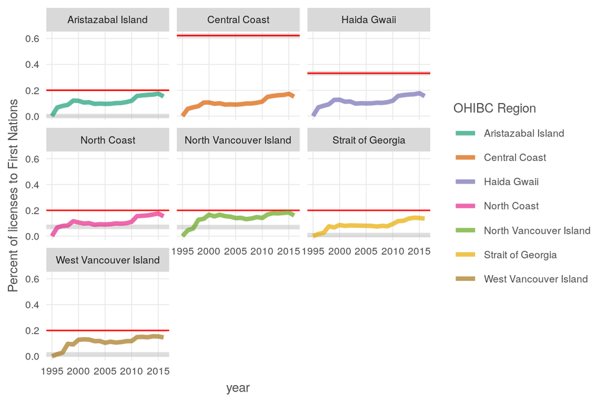

```r
license_ref_min <- 0.20 ### arbitrary lower limit of reference point

license_status <- read_csv(file.path(dir_goal, 'output/ao_licenses.csv')) %>%
  filter(rgn_id != 7) %>%
  left_join(read_csv(file.path(dir_goal, 'output/ao_licenses_fn_pop.csv')),
            by = 'rgn_id') %>%
  mutate(ref_pt = ifelse(pct_fn_pop > license_ref_min, pct_fn_pop, license_ref_min),
         status = pct_fn / ref_pt,
         status = ifelse(status > 1, 1, status),
         component = 'first_nations_licenses') %>%
  select(year, rgn_id, pct_fn, pct_fn_pop, ref_pt, status, component) %>%
  left_join(get_rgn_names(), by = 'rgn_id')


plot_fn_by_rgn <- ggplot(license_status, aes(x = year, y = pct_fn, group = rgn_name, color = rgn_name)) +
  ggtheme_plot() +
  geom_hline(aes(yintercept = pct_fn_pop), color = 'grey', size = 1.5, alpha = .5) +
  geom_hline(aes(yintercept = ref_pt), color = 'red', alpha = 1) +
  geom_line(size = 1.5, alpha = 0.7) +
  labs(y = 'Percent of licenses to First Nations',
       color = 'OHIBC Region') +
  scale_color_brewer(palette = 'Dark2') +
  facet_wrap( ~ rgn_name)

print(plot_fn_by_rgn)
```

Note: grey line indicates % of rgn population that are members of First Nations communities according to 2016 census subdivisions; red line indicates reference point as proportion of region population that is First Nations, with a minimum set at 20%.

```r
pop_fn_rgn <- read_csv(file.path(dir_goal, 'int/ao_licenses_fn_pop.csv'))

fn_by_rgn <- read_csv(file.path(dir_goal, 'output/ao_licenses.csv')) %>%
  left_join(get_rgn_names(), by = 'rgn_id') %>%
  left_join(pop_fn_rgn, by = 'rgn_id') %>%
  filter(rgn_id != 7) %>%
  rename(pct_fn_lic = pct_fn)

fn_by_rgn_mean <- fn_by_rgn %>%
  group_by(rgn_id, rgn_name, pct_fn_pop, fn_pop) %>%
  summarize(pct_fn_lic = mean(pct_fn_lic, na.rm = TRUE),
            n_fn = mean(n_fn, na.rm = TRUE)) %>%
  ungroup()

x <- ggplot(fn_by_rgn, aes(x = pct_fn_pop, y = pct_fn_lic)) +
  geom_abline(slope = 1, intercept = 0, color = 'red') +
  geom_point(aes(color = rgn_name), alpha = .3) +
  geom_point(data = fn_by_rgn_mean, aes(color = rgn_name), size = 4) +
  labs(title = 'FN % licenses vs % rgn pop')

y_mdl <- lm(n_fn ~ fn_pop, data = fn_by_rgn)
y_coef <- c('slope' = y_mdl$coefficients[['fn_pop']],
            'intcp' = y_mdl$coefficients[['(Intercept)']],
            'r2'    = y_mdl %>% summary() %>% .$r.squared)

mean_ratio <-  fn_by_rgn %>%
  group_by(rgn_id) %>%
  summarize(mean_n = mean(n_fn),
            mean_fn_pop = mean(fn_pop),
            mean_ratio = mean(n_fn / fn_pop)) %>%
  ungroup() %>%
  filter(rgn_id != 8) %>%
  mutate(unif_dist = sum(mean_n) / sum(mean_fn_pop))

y <- ggplot(fn_by_rgn, aes(x = fn_pop, y = n_fn)) +
  geom_smooth(method = 'lm', color = 'red') +
  geom_point(aes(color = rgn_name), alpha = .3) +
  geom_point(data = fn_by_rgn_mean, aes(color = rgn_name), size = 4) +
  labs(title = 'FN licenses vs rgn pop')


print(x); print(y)
```

[output not shown]

## 3.6 Other questions

### 3.6.1 licenses by length?

Do licensed vessels differ greatly between the First Nations fleet and the non-First Nations fleet? A significant difference in boat size could indicate a significant difference in the access to catch for one license type vs. another.

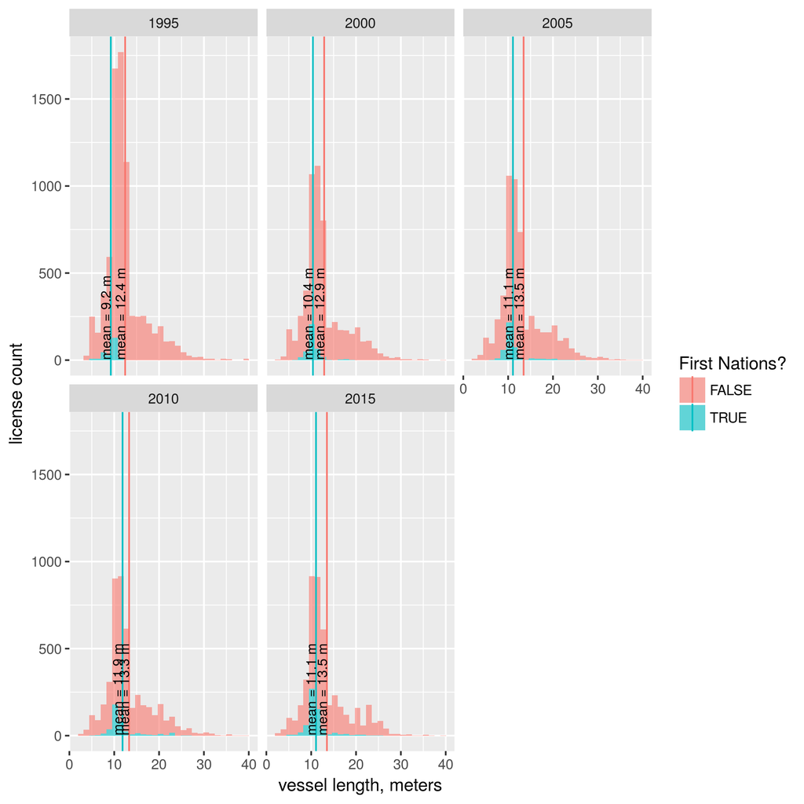

```r
boats <- read_csv(lic_clean_file, nogit = TRUE) %>%
  select(year, fishery_group, fn, length = vessel_length_m, lic_holder, lic_oper) %>%
  mutate(length = ifelse(length == 0, NA, length))

bigboats <- boats %>%
  filter(length > 50)

medboats <- boats %>%
  group_by(year, fn) %>%
  mutate(mean_l = mean(length, na.rm = TRUE)) %>%
  ungroup() %>%
  filter(length <= 40) %>%
  filter(year %in% c(1995, 2000, 2005, 2010, 2015))

length_hist <- ggplot(medboats, aes(x = length, fill = fn)) +
  geom_histogram(aes(frame = year), alpha = .6) +
  geom_vline(aes(xintercept = mean_l, color = fn)) +
  geom_text(data = medboats %>%
              select(year, mean_l, fn) %>%
              distinct(),
            aes(x = mean_l, y = 1, label = paste0('mean = ', round(mean_l, 1), ' m')),
            hjust = 0, vjust = 0, angle = 90, size = 3) +
  labs(x = 'vessel length, meters',
       y = 'license count',
       fill = 'First Nations?',
       color = 'First Nations?') +
  facet_wrap( ~ year)

# print(length_hist)

ggsave(file.path(dir_goal, 'int/ao_licenses_vessel_lengths.png'))
```

### 3.6.2 licenses by area intensity and type

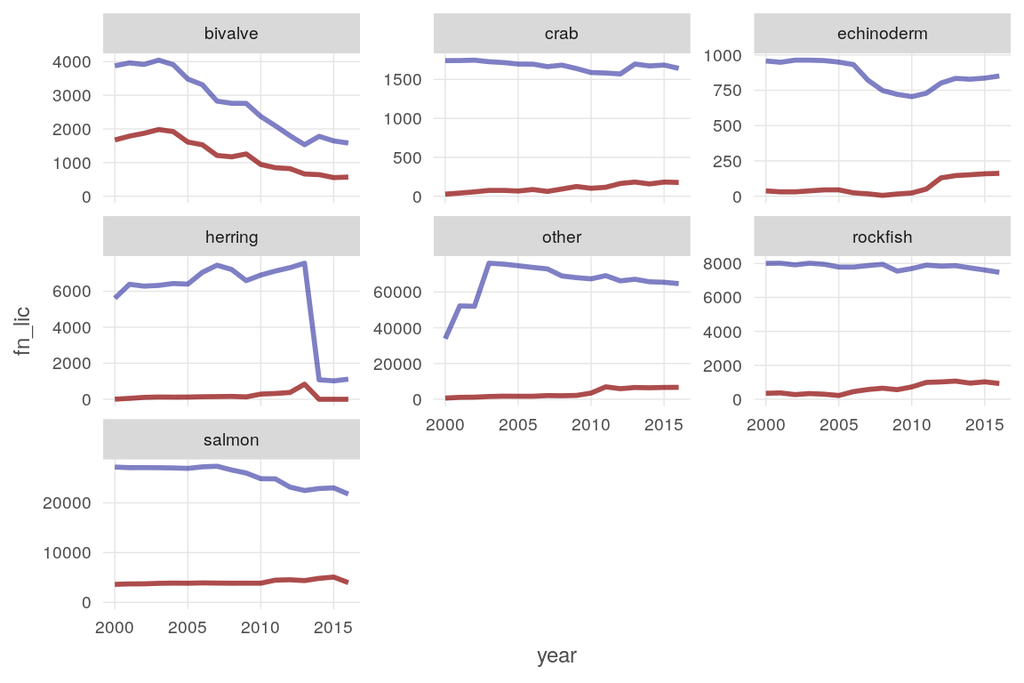

```r
lic_lookup_rgn <- read_csv(file.path(dir_goal, 'int/lic_lookup_rgn.csv')) %>%
  filter(!is.na(rgn_id))

lic_clean <- read_csv(lic_clean_file,
                      col_types = cols(.default = 'c')) %>%
  mutate(year = as.integer(year),
         fn   = as.logical(fn),
         area = tolower(area))

lic_by_pfma_all <- lic_clean %>%
  inner_join(lic_lookup_rgn, by = c('area' = 'lic_area')) %>%
  select(-rgn_id) %>%
  distinct()

### Total licenses by fishery group:
# lic_by_pfma_all$fishery_group %>% table()
#             CLAM                    CRAB  GEODUCK AND HORSE CLAM                 HERRING   HERRING - FOOD & BAIT HERRING - SPECIAL ISSUE
#           113384                   48600                    4024                      74                    4760                     348
# OYSTERS, PACIFIC              PROCESSING          RED SEA URCHIN                ROCKFISH    ROE HERRING GILL NET       ROE HERRING SEINE
#             1650                     283                   14776                  331645                   89560                   16515
#  SALMON GILL NET       SALMON HISTORICAL            SALMON SEINE            SALMON TROLL            SEA CUCUMBER
#           316457                      20                   97852                  208194                    6047

### FN licenses by fishery group:
# lic_by_pfma_all %>% filter(fn) %>% .$fishery_group %>% table()
#              CLAM                   CRAB GEODUCK AND HORSE CLAM       OYSTERS, PACIFIC         RED SEA URCHIN               ROCKFISH   ROE HERRING GILL NET
#             24405                   1898                      9                    156                   1266                  12061                   3750
# ROE HERRING SEINE        SALMON GILL NET           SALMON SEINE           SALMON TROLL           SEA CUCUMBER
#               236                  75222                   4271                   6914                     10

### These have NO fn licenses:
# lic_by_pfma_all %>% group_by(fishery_group) %>% filter(sum(fn) == 0) %>% .$fishery_group %>% table()
# HERRING   HERRING - FOOD & BAIT HERRING - SPECIAL ISSUE              PROCESSING       SALMON HISTORICAL
#      74                    4760                     348                     283                      20

lic_by_pfma <- lic_by_pfma_all %>%
  select(year, lic_tab, fn, fishery_group, desc, pfma) %>%
  mutate(taxa = case_when(str_detect(fishery_group, 'CLAM|OYSTER') ~ 'bivalve',
                          str_detect(fishery_group, 'SALMON')      ~ 'salmon',
                          str_detect(fishery_group, 'HERRING')     ~ 'herring',
                          str_detect(fishery_group, 'CRAB')        ~ 'crab',
                          str_detect(fishery_group, 'URCH|CUCUM')  ~ 'echinoderm',
                          str_detect(fishery_group, 'ROCKFISH')    ~ 'rockfish',
                          str_detect(fishery_group, 'PROCESS')     ~ 'processing',
                          TRUE                                     ~ 'other')) %>%
  group_by(year, pfma, taxa, fn) %>%
  summarize(n_lic = n()) %>%
  ungroup()

write_csv(lic_by_pfma, file.path(dir_goal, 'int/lic_by_pfma.csv'))

lic_by_year <- lic_by_pfma %>%
  group_by(year, taxa) %>%
  summarize(fn_lic = sum(n_lic * fn),
            tot_lic = sum(n_lic)) %>%
  ungroup() %>%
  filter(year >= 2000 & year <= 2016) %>%
  filter(taxa != 'processing')

plot_by_year <- ggplot(lic_by_year, aes(x = year)) +
  ggtheme_plot() +
  geom_line(aes(y = fn_lic, group = taxa),
            color = 'darkred', alpha = .7, size = 1) +
  geom_line(aes(y = tot_lic, group = taxa),
            color = 'darkblue', alpha = .5, size = 1) +
  scale_color_brewer(palette = 'Dark2') +
  facet_wrap( ~ taxa, scales = 'free_y') +
  ylim(c(0, NA))

print(plot_by_year)
```

```r
ggsave(file.path(dir_goal, 'figs/licenses/lic_by_year_and_taxa.png'))
```

```r
lic_by_pfma_tot <- read_csv(file.path(dir_goal, 'int/lic_by_pfma.csv')) %>%
  filter(year >= 2000 & year <= 2016) %>%
  group_by(pfma, taxa) %>%
  summarize(fn_lic = sum(n_lic * fn),
            tot_lic = sum(n_lic)) %>%
  ungroup()


pfma_sf <- sf::read_sf(dsn = file.path(dir_anx, '_raw_data/dfo_khunter',
                                 'management_boundaries/d2016',
                                 'pac_fishery_mgmt_areas'),
                       layer = 'DFO_BC_PFMA_AREAS_50K_V3_1') %>%
  select(pfma = STATAREA)

bbx <- st_bbox(pfma_sf)[c(1, 3, 2, 4)] %>%
  raster::extent()

garbage <- capture.output({
  continent_sf <- readOGR(dsn = path.expand(file.path(dir_spatial)),
                          layer = 'ohibc_continent') %>%
    raster::crop(bbx) %>%
    sf::st_as_sf()
})


pfma_lic_sf <- pfma_sf %>%
  left_join(lic_by_pfma_tot, by = 'pfma') %>%
  filter(!is.na(taxa))

for(taxa_sel in unique(pfma_lic_sf$taxa)) {
  ### taxa_sel <- 'herring'
  # cat(taxa_sel, '\n')

  tmp_df <- pfma_lic_sf %>%
    filter(taxa == taxa_sel) %>%
    mutate(tot_lic = ifelse(tot_lic == 0, NA, tot_lic),
           fn_lic = ifelse(fn_lic == 0, NA, fn_lic))

  breaks <- c(1, 10, 100, 1000, 10000)
  max_tot <- tmp_df$tot_lic %>% max(na.rm = TRUE)
  breaks_tot <- breaks[breaks < max_tot * 10]

  tot_map <- ggplot(tmp_df %>% filter(!is.na(tot_lic))) +
    ggtheme_plot() +
    geom_sf(data = continent_sf, fill = '#bb9999', color = NA) +
    geom_sf(data = pfma_sf, fill = 'grey96',
            color = 'black', size = .1) +
    geom_sf(aes(fill = tot_lic),
            color = NA, alpha = .8) +
    scale_fill_distiller(palette = 'Blues',
                         breaks = breaks_tot,
                         limits = c(1, NA),
                         trans = 'log', direction = 1) +
    labs(title = taxa_sel,
         fill  = 'Total licenses')

  print(tot_map)

  ggsave(file.path(dir_goal, sprintf('figs/licenses/lic_map_pfma_%s_total.png', taxa_sel)))

  tmp_df_fn <- tmp_df %>% filter(!is.na(fn_lic))
  if(nrow(tmp_df_fn) > 0) {
    max_fn  <- tmp_df$fn_lic  %>% max(na.rm = TRUE)
    breaks_fn  <- breaks[breaks < max_fn  * 10]

    fn_map <- ggplot(tmp_df_fn) +
      ggtheme_plot() +
      geom_sf(data = continent_sf, fill = '#bb9999', color = NA) +
      geom_sf(data = pfma_sf, fill = 'grey96',
              color = 'black', size = .1) +
      geom_sf(aes(fill = fn_lic),
              color = NA, alpha = .8) +
      scale_fill_distiller(palette = 'Blues',
                           breaks = breaks_fn,
                           limits = c(1, NA),
                           trans = 'log', direction = 1) +
      labs(title = taxa_sel,
           fill  = 'FN licenses')

    print(fn_map)
    ggsave(file.path(dir_goal, sprintf('figs/licenses/lic_map_pfma_%s_fn.png', taxa_sel)))
  }
}
```

[output not shown]

```r
prov_wrapup(commit_outputs = FALSE)
```